```
---
title: "Lab 4"
author:  Apurva Shah 705595011
date: "2022-05-01"
output:
  pdf_document:
    toc: yes
    toc_depth: '3'
  html_document:
    theme: paper
    toc: yes
    toc_depth: 3
    toc_float: yes
---
\fontsize{10}{11}

&nbsp;&nbsp;
```

## Date last run: 2022-05-01

## Hello World!

````
&nbsp;&nbsp;

# Examples

Requires library xtable.


&nbsp;&nbsp;




## NFL 2021 Season Total Team Offense




```r
#### note ``` (3 backticks)
##### R code goes in here.  Set code chunk environment options above

## We have an Excel file
library(gdata)

## Read in our data
xdf <- read.xls("NFL_offense_passing_2021.xlsx", sheet=1, header=TRUE)

head(xdf, n=6)
````

```
##      Team Att Cmp Cmp.. Yds.Att Pass.Yds TD INT  Rate X1st X1st. X20 X40 Lng Sck SckY
## 1   49ers 514 343  66.7     8.6     4437 26  14  99.2  200  38.9  63  11  83  33  216
## 2   Bears 542 332  61.3     6.7     3635 16  20  75.5  180  33.2  40   7  64  58  428
## 3 Bengals 555 384  69.2     8.7     4806 36  14 106.9  208  37.5  63  16 82T  55  403
## 4   Bills 655 415  63.4     6.8     4450 36  16  91.3  236  36.0  51   8  61  27  166
## 5 Broncos 541 354  65.4     7.1     3856 20   9  91.7  179  33.1  46   7  64  40  263
## 6  Browns 520 320  61.5     7.0     3619 21  14  84.6  177  34.0  47   9 71T  49  299
##   totalPoints
## 1         427
## 2         311
## 3         460
## 4         483
## 5         335
## 6         349
```

Rate: passer rating (NFL QB rating)

This data set was made by processing data obtained from NFL.com

Let’s create the distribution of total season team points. totalPoints appears to be numerical; an integer. What does R think?

```r
class(xdf[ , "totalPoints"])
```

```
## [1] "integer"
```

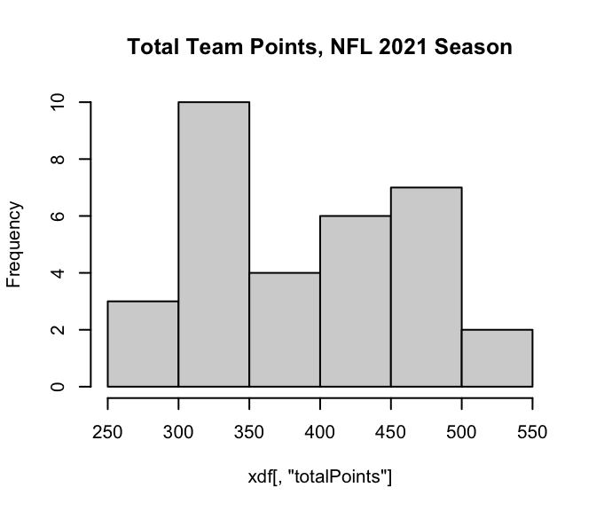

Distribution of Total Team Points

```r
### the par() function allows us to set parameters of subsequent graphic.
### here we set cex parameter, which controls the relative size of assets like title font
par(cex=0.65)
hist(xdf[ , "totalPoints"], main="Total Team Points, NFL 2021 Season")
```

Let’s create the distribution of season game average QB rating. Rate appears to be numerical. What does R think?

```r
class(xdf[ , "Rate"])
```

```
## [1] "numeric"
```

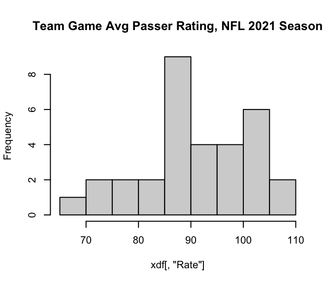

Distribution of Average Team Passer Rating

```r
par(cex=0.65)
hist(xdf[ , "Rate"], main="Team Game Avg Passer Rating, NFL 2021 Season")
```

### Bivariate Association.

By far the most popular way to graphically convey the bivariate relationship between two numeric attributes is the scatterplot.

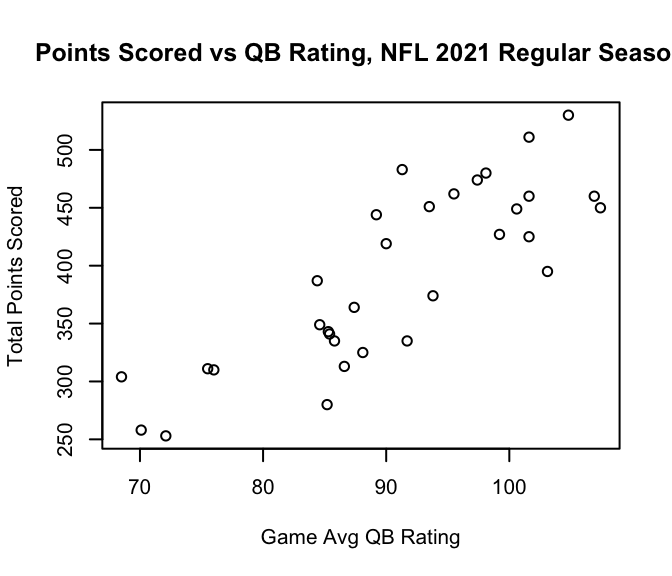

Scatterplot of total points scored vs QB rating, NFL 2021 regular season

```r
par(cex=0.65)
plot(
  xdf[ , "Rate"],
  xdf[ , "totalPoints"],
  xlab="Game Avg QB Rating",
  ylab="Total Points Scored",
  main="Points Scored vs QB Rating, NFL 2021 Regular Season"
  )
```

Let’s make this a little prettier.

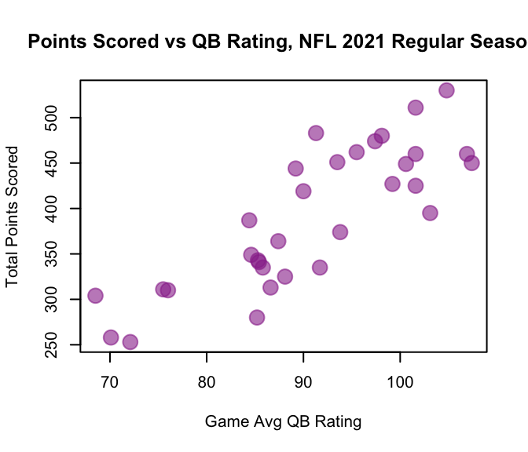

Scatterplot of total points scored vs QB rating, NFL 2021 regular season

```r
par(cex=0.65)
plot(
  xdf[ , "Rate"],
  xdf[ , "totalPoints"],
  xlab="Game Avg QB Rating",
  ylab="Total Points Scored",
  pch=19,
  cex=2,
  col="#99339999",
  main="Points Scored vs QB Rating, NFL 2021 Regular Season"
  )
```

Let’s calculate some important univariate statistics.

```r
xmeanPR <- mean(xdf[ , "Rate"])
xmeanPR
```

```
## [1] 90.69688
```

```r
xmeanPnts <- mean(xdf[ , "totalPoints"])
xmeanPnts
```

```
## [1] 390.6875
```

```r
##### sample standard deviation of rating
xsdPR <- sd(xdf[ , "Rate"])
xsdPR
```

```
## [1] 10.62254
```

```r
##### sample standard deviation of total points
xsdPnts <- sd(xdf[ , "totalPoints"])
xsdPnts
```

```
## [1] 76.61358
```

Now let’s perform a detailed calculation of some important bivariate statistics.

```r
### sample size
n <- nrow(xdf)
n
```

```
## [1] 32
```

```r
###### sample covariance
xcov <- sum( (xdf[ , "Rate"] - xmeanPR) * (xdf[ , "totalPoints"] - xmeanPnts) ) / (n - 1)
xcov
```

```
## [1] 674.5183
```

```r
###### sample correlation
xcorr <- xcov / (xsdPR * xsdPnts)
xcorr
```

```
## [1] 0.8288188
```

```r
###### sample regression line slope
xb1 <- xcorr * xsdPnts / xsdPR
xb1
```

```
## [1] 5.977739
```

```r
###### sample regression line y-intercept
xb0 <- xmeanPnts - xb1 * xmeanPR
xb0
```

```
## [1] -151.4747
```

Let’s drop our LS line into our scatterplot.

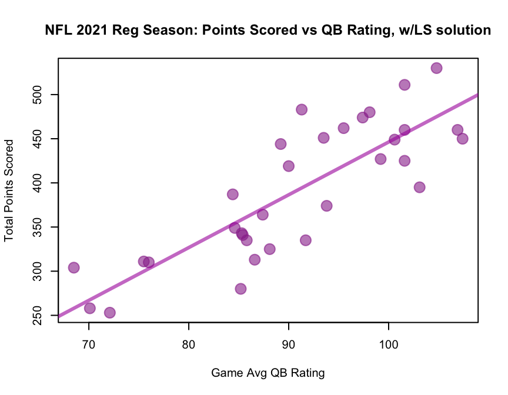

Scatterplot of points scored vs QB rating, NFL 2021 regular season with LS solution

```r
par(cex=0.63)
plot(
  xdf[ , "Rate"],
  xdf[ , "totalPoints"],
  xlab="Game Avg QB Rating",
  ylab="Total Points Scored",
  pch=19,
  cex=2,
  col="#99339999",
  main="NFL 2021 Reg Season: Points Scored vs QB Rating, w/LS solution"
  )

abline(a=xb0, b=xb1, lwd=3, col="#AA00AA99")
```

### Context

Let’s verbally put things into context:

Considering the 2021 NFL season, looking at team totals . . .

We have a total of 32 teams.

The average total team points scored over the season is 390.69 points.

The average of the game average team passer rating over the season is 90.7 rating points.

The covariance between total team points scored and game average passer rating is 674.52.

Pearson’s correlation between total team points scored and game average passer rating is 0.8288.

If we fit an SLR (simple linear regression) line to total team points over game-average team passer rating, we obtain a slope of 5.978 and a y-intercept of -151.475.

One interpretation of this trend would be that a 10 unit increase in passer rating is associated with a 59.777 units increase — on average — in total team points scored over the season.

### All at Once

includes a high-level function that performs all the regression calculations.

The lm() function.

```r
x <- xdf[ , "Rate"]
y <- xdf[ , "totalPoints"]

xlm <- lm(y ~ x)

summary(xlm)
```

```
##
## Call:
## lm(formula = y ~ x)
##
## Residuals:
##     Min      1Q  Median      3Q     Max
## -77.829 -28.375  -6.111  42.761  88.707
##
## Coefficients:
##              Estimate Std. Error t value Pr(>|t|)
## (Intercept) -151.4747    67.2650  -2.252   0.0318 *
## x              5.9777     0.7368   8.113 4.67e-09 ***
## ---
## Signif. codes:  0 '***' 0.001 '**' 0.01 '*' 0.05 '.' 0.1 ' ' 1
##
## Residual standard error: 43.58 on 30 degrees of freedom
## Multiple R-squared:  0.6869, Adjusted R-squared:  0.6765
## F-statistic: 65.83 on 1 and 30 DF,  p-value: 4.674e-09
```

# Your Work

Make sure to edit the “author” information in the YAML header near the top to include your name and UID.

Complete/answer the following.

1 — Does our NFL team data represent “stacked” data? Why or why not?

The NFL team data does not represent stacked data because the rows are independent from each other and the data does not form a stack that is dependent on what is before it.

2 — Each team played 17 regular season games. Calculate the average points scored per game for each team. Create a scatterplot showing avg team points versus avg passer ratings with the least squares line …

> 2a — Does this plot visually look similar to its counterpart using season total points above? …

> 2b — Is the Pearson’s correlation coefficient the same or different? Why?

```r
library(xtable)
library(tidyverse)
library(readxl)
library(ggthemes)

xdf <- read_excel("/Users/apurvashah/Documents/GitHub/stats10/lab4/NFL_offense_passing_2021.xlsx", sheet=1, col_names = TRUE, skip = 1)
head(xdf, n=6)
```

```
## # A tibble: 6 × 17
##   Team      Att   Cmp `Cmp %` `Yds/Att` `Pass Yds`    TD   INT  Rate `1st` `1st%`  `20`
##   <chr>   <dbl> <dbl>   <dbl>     <dbl>      <dbl> <dbl> <dbl> <dbl> <dbl>  <dbl> <dbl>
## 1 49ers     514   343    66.7       8.6       4437    26    14  99.2   200   38.9    63
## 2 Bears     542   332    61.3       6.7       3635    16    20  75.5   180   33.2    40
## 3 Bengals   555   384    69.2       8.7       4806    36    14 107.    208   37.5    63
## 4 Bills     655   415    63.4       6.8       4450    36    16  91.3   236   36      51
## 5 Broncos   541   354    65.4       7.1       3856    20     9  91.7   179   33.1    46
## 6 Browns    520   320    61.5       7         3619    21    14  84.6   177   34      47
## # … with 5 more variables: 40 <dbl>, Lng <chr>, Sck <dbl>, SckY <dbl>, totalPoints <dbl>
```

```r
x <- data.frame(Team = xdf$Rate, avg = xdf$totalPoints)
head(x)
```

```
##    Team avg
## 1  99.2 427
## 2  75.5 311
## 3 106.9 460
## 4  91.3 483
## 5  91.7 335
## 6  84.6 349
```

```r
x$avg = round(x$avg/17, 2)

# head(x)

xmeanPR <- mean(x$Team)
xmeanPR
```

```
## [1] 90.69688
```

```r
xmeanPnts <- mean(x$avg)
xmeanPnts
```

```
## [1] 22.9825
```

```r
##### sample standard deviation of rating
xsdPR <- sd(x$Team)
xsdPR
```

```
## [1] 10.62254
```

```r
##### sample standard deviation of total points
xsdPnts <- sd(x$avg)
xsdPnts
```

```
## [1] 4.50699
```

```r
n <- nrow(xdf)
n
```

```
## [1] 32
```

```r
###### sample covariance
xcov <- sum((x$Team - xmeanPR) * (x$avg - xmeanPnts) ) / (n - 1)
xcov
```

```
## [1] 39.68362
```

```r
###### sample correlation
xcorr <- xcov / (xsdPR * xsdPnts)
xcorr
```

```
## [1] 0.8288888
```

```r
###### sample regression line slope
xb1 <- xcorr * xsdPnts / xsdPR
xb1
```

```
## [1] 0.3516855
```

```r
###### sample regression line y-intercept
xb0 <- xmeanPnts - xb1 * xmeanPR
xb0
```

```
## [1] -8.914276
```

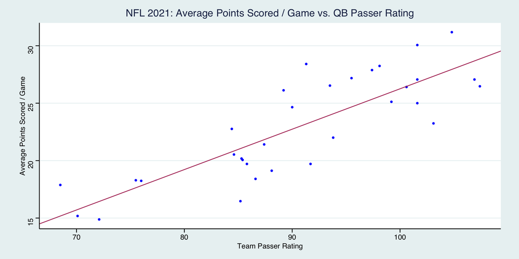

```r
graph <- ggplot(data = x,  aes(Team, avg)) + geom_point(size = 1, color = "blue") +
  labs(title = "NFL 2021: Average Points Scored / Game vs. QB Passer Rating",
       x = "Team Passer Rating", y = "Average Points Scored / Game") + theme_stata() +
  geom_abline(slope=xb1, intercept=xb0, color = "maroon")

graph
```

The graph look very similar to the one above because the only difference would be in the how all of the data is scaled. The correlation coefficient is the same because the data is the same just scaled differently.

3 — Read in the NHL team-game data, and examine the relationship between assists and goals (for the regression part, goals are the outcome, assists are the predictor, i.e., regress goals on assists).

```r
xdf <- read_tsv("/Users/apurvashah/Documents/GitHub/stats10/lab4/NHL_20202021_teamGame.tsv", col_names = TRUE)
head(xdf)
```

```
## # A tibble: 6 × 23
##       date   season team            VorH  team_goals team_pim team_shots team_powerPlayGo…
##      <dbl>    <dbl> <chr>           <chr>      <dbl>    <dbl>      <dbl>             <dbl>
## 1 20210113 20202021 Pittsburgh Pen… VT             3        6         34                 1
## 2 20210113 20202021 Philadelphia F… HT             6        6         27                 2
## 3 20210113 20202021 Chicago Blackh… VT             1        8         23                 1
## 4 20210113 20202021 Tampa Bay Ligh… HT             5        6         33                 2
## 5 20210113 20202021 Montréal Canad… VT             4       13         32                 2
## 6 20210113 20202021 Toronto Maple … HT             5       11         34                 2
## # … with 15 more variables: team_powerPlayOpportunities <dbl>, team_blocked <dbl>,
## #   team_takeaways <dbl>, team_giveaways <dbl>, team_hits <dbl>, assists <dbl>,
## #   goals <dbl>, shots <dbl>, powerPlayGoals <dbl>, powerPlayAssists <dbl>,
## #   penaltyMinutes <dbl>, faceOffWins <dbl>, faceoffTaken <dbl>, shortHandedGoals <dbl>,
## #   shortHandedAssists <dbl>
```

```r
x <- data.frame(Team = xdf$goals, avg = xdf$assists)
head(x)
```

```
##   Team avg
## 1    3   3
## 2    6  11
## 3    1   2
## 4    5  10
## 5    4   8
## 6    5   8
```

```r
xmeanPR <- mean(x$Team)
xmeanPR
```

```
## [1] 2.898041
```

```r
xmeanPnts <- mean(x$avg)
xmeanPnts
```

```
## [1] 4.87788
```

```r
##### sample standard deviation of rating
xsdPR <- sd(x$Team)
xsdPR
```

```
## [1] 1.711624
```

```r
##### sample standard deviation of total points
xsdPnts <- sd(x$avg)
xsdPnts
```

```
## [1] 3.009314
```

```r
n <- nrow(xdf)
n
```

```
## [1] 1736
```

```r
###### sample covariance
xcov <- sum((x$Team - xmeanPR) * (x$avg - xmeanPnts) ) / (n - 1)
xcov
```

```
## [1] 4.846908
```

```r
###### sample correlation
xcorr <- xcov / (xsdPR * xsdPnts)
xcorr
```

```
## [1] 0.9409984
```

```r
###### sample regression line slope
xb1 <- xcorr * xsdPnts / xsdPR
xb1
```

```
## [1] 1.654429
```

```r
###### sample regression line y-intercept
xb0 <- xmeanPnts - xb1 * xmeanPR
xb0
```

```
## [1] 0.08327668
```

4 — With NHL team-game data, can we argue that increasing assists causes more goals?

Although when looking at the data, we can see that when there are more assists, there generally more goals, since we did not conduct and experiment and did not use random assignment we cannot assume causality here. We can say that there is a correlation.

5 — Back to the NFL data, can we say that improving passer rating causes more points to be scored?

Note that 4 and 5 are intended to test your reasoning. These questions may not be as simple as they appear.

Although we might see a trend that teams with better passer ratings cause more points to be scored we cannot say that this causes more points to be scored because we did not conduct a true experiment to test this. We cannot assume causality and at most can say that there might be a correlation between these two.